# NYPD Shooting Incident Data (Historic) Analysis

Rajesh Sharma

2/20/2022

## R Packages used

Tidyverse packages For more info on tidyverse packages that we will be using, go to https://www.tidyverse.org/packages/

```r
library(tidyverse)
library(lubridate)
```

# Analysis of “NYPD Shooting Incident Data data”

## Source of Data

Data used in this Analysis is used from the City of New York Dataset available for public consumption from https://data.cityofnewyork.us.

1. NYPD Shooting Incident Data (Historic) data from https://data.cityofnewyork.us/api/views/833y-fsy8/rows.csv
2. New York City Borough population data from https://data.cityofnewyork.us/api/views/xywu-7bv9/rows.csv
3. New York Unemployment Data from Federal Reserve Bank of St. Louis https://fred.stlouisfed.org/graph/fredgraph.csv?bgcolor=%23e1e9f0&chart_type=line&drp=0&fo=open%20sans&graph_bgcolor=%23ffffff&height=450&mode=fred&recession_bars=on&txtcolor=%23444444&ts=12&tts=12&width=1168&nt=0&thu=0&trc=0&show_legend=yes&show_axis_titles=yes&show_tooltip=yes&id=NYUR&scale=left&cosd=1976-01-01&coed=2021-12-01&line_color=%234572a7&link_values=false&line_style=solid&mark_type=none&mw=3&lw=2&ost=-99999&oet=99999&mma=0&fml=a&fq=Monthly&fam=avg&fgst=lin&fgsnd=2020-02-01&line_index=1&transformation=lin&vintage_date=2022-01-30&revision_date=2022-01-30&nd=1976-01-01

```r
## get url of the data

nypd_data_url <- "https://data.cityofnewyork.us/api/views/833y-fsy8/rows.csv"

## load the data
nypd_shooting_data <- read_csv(nypd_data_url)
```

## Clean the Data set by removing uneccessary fields.

```r
nypd_shooting_data <- nypd_shooting_data %>%
                      select(OCCUR_DATE,OCCUR_TIME, BORO,PERP_AGE_GROUP,
                             PERP_SEX, PERP_RACE, VIC_AGE_GROUP, VIC_SEX,
                             VIC_RACE, STATISTICAL_MURDER_FLAG) %>%
                      mutate(OCCUR_DATE=mdy(OCCUR_DATE))
```

## Data Analysis 1

Count the occurrences of incidents per hour during a day to give an idea of the frequent shooting time. My understanding is that crime is higher late at night when fewer people are in the street.

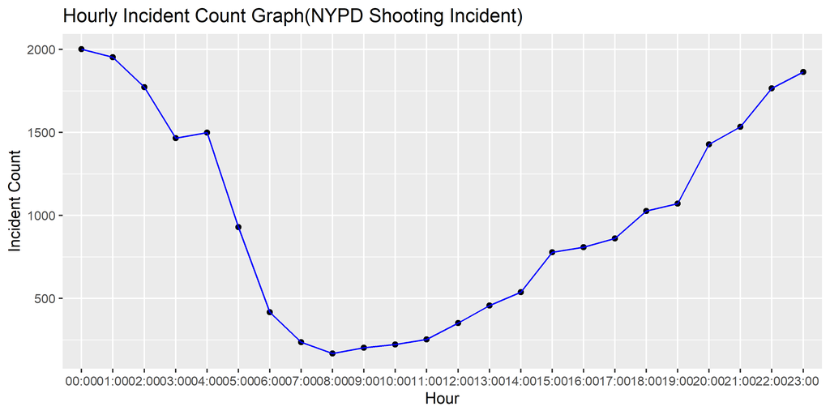

```r
## round the occur_time to hours to simplify the analysis, strip function will stip minute and seconds from the time

nypd_shooting_data <- nypd_shooting_data %>%
                  mutate(OCCUR_TIME=format(round(strptime(paste("2001-01-01",
                                          OCCUR_TIME), format="%Y-%m-%d %H:%M"),
                                          units="hours"), format="%H:%M"))

nypd_shooting_hourly_data <- nypd_shooting_data %>%
                            group_by(OCCUR_TIME) %>%
                            tally(  name = "incidents_per_hour") %>%
                            ungroup()

 nypd_shooting_hourly_data_plot <- nypd_shooting_hourly_data %>% ggplot() +
   geom_point(aes(x=OCCUR_TIME, y=incidents_per_hour))+
  geom_line(aes(x=OCCUR_TIME, y=incidents_per_hour , group = 1), color="blue")+
 labs(x="Hour", y="Incident Count",
title="Hourly Incident Count Graph(NYPD Shooting Incident)")

 ggsave("nypd_shooting_hourly_data.png", nypd_shooting_hourly_data_plot,
        height=4, width=8, units="in",  dpi=450)

knitr::include_graphics("nypd_shooting_hourly_data.png")
```

## Conclusion

When the number of shooting incidents was analyzed I found out that crime rates increase as darkness and fewer people are on street and it comes down after midnight. The lowest crime is at 8 AM when most of the people are commuting to the office.

## Data Analysis 2

I want to find out if all boroughs of New York City crime count are following the same pattern year after year.

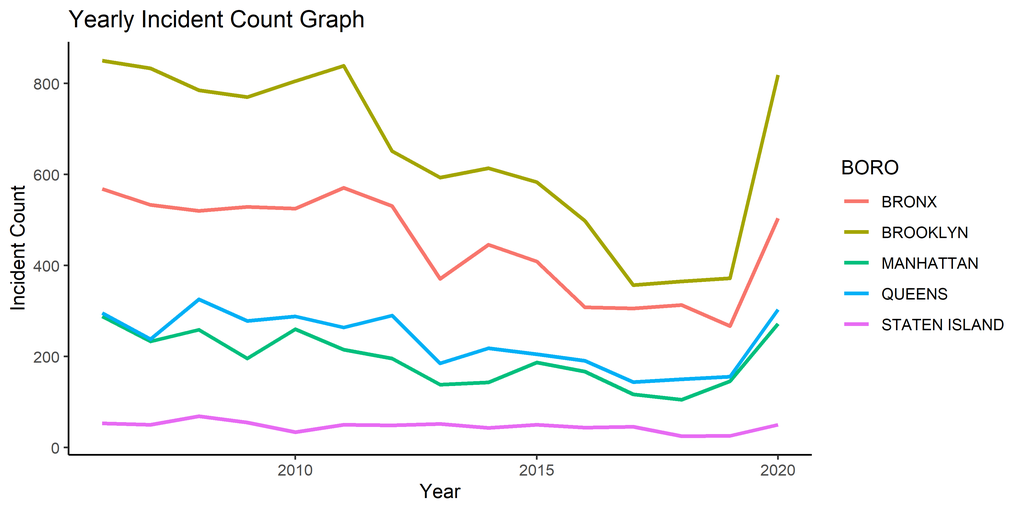

```r
## Group by the data to yearly and per borough
nypd_boro_shooting_by_year <- nypd_shooting_data %>%
                group_by(BORO, year=year(OCCUR_DATE)) %>%
               tally( name = "incident_per_year") %>%
                            ungroup()

nypd_shooting_year_boro_plot <- nypd_boro_shooting_by_year %>%
                              ggplot(aes(x=year, y=incident_per_year, colour=BORO))+
                              geom_line(size=1) +
                              theme_classic() +
                              labs(x="Year", y="Incident Count",
                                title="Yearly Incident Count Graph")

 ggsave("nypd_shooting_year_boro.png", nypd_shooting_year_boro_plot,
        height=4, width=8, units="in",  dpi=450)

knitr::include_graphics("nypd_shooting_year_boro.png")
```

## Data Analysis 3

I want to find out if all boroughs of New York City crime count are following the same pattern year after year based on population.

This data will be cleaned by following steps:

1. Select the coloum which are useful for us
2. Remove uneccesary rows
3. pivot the data
4. convert data as per the need

```r
## get population
ny_population_data_url <-"https://data.cityofnewyork.us/api/views/xywu-7bv9/rows.csv"

ny_population_data <- read_csv(ny_population_data_url)
```

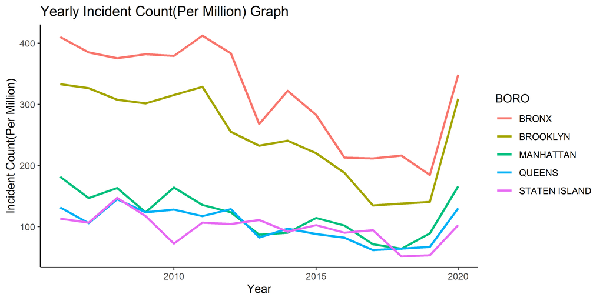

```r
## Tidy and clean the data
ny_population_data <- ny_population_data %>%
                      select(c(2,seq(3, by = 2, len = 10))) %>%
                      slice(2:n())%>%
                      pivot_longer(cols = -c(Borough), names_to = "year",
                            values_to = "population") %>%
                      mutate(year=parse_number(year)) %>%
                      mutate(Borough = str_to_upper(Borough))

## Group by the data to yearly and per borough
nypd_boro_shooting_by_year <- nypd_shooting_data %>%
                              group_by(BORO, year=year(OCCUR_DATE)) %>%
                              tally( name = "incident_per_year")  %>%
                              mutate(decade = round(year,-1))  %>%
                            ungroup()



## Join with the population to add population to the data
nypd_boro_shooting_by_year_with_population <- nypd_boro_shooting_by_year %>%
            left_join(ny_population_data, by = c("BORO" = "Borough", "decade"="year")) %>%
            mutate(incidents_per_mill=incident_per_year*1000000/population)


nypd_shooting_year_boro_pop_plot <- nypd_boro_shooting_by_year_with_population %>%
  ggplot(aes(x=year, y=incidents_per_mill, colour=BORO))+
  geom_line(size=1) +
  theme_classic() +
  labs(x="Year", y="Incident Count(Per Million)",
title="Yearly Incident Count(Per Million) Graph")

 ggsave("nypd_shooting_year_boro_pop.png", nypd_shooting_year_boro_pop_plot,
        height=4, width=8, units="in",  dpi=450)

knitr::include_graphics("nypd_shooting_year_boro_pop.png")
```

## Conclusion

As we can see the incident count of all the boroughs is following the same pattern, which was not that clear in the last graph for Staten LIslandsland. This also shows that the Bronx is the Borough with a high crime rate and more resources are needed in that borough to improve the situation. Brooklyn is second highest in crime rate per million of population and rests all Borough are having Similar shooting incidents.

## Model- Try to find out if unemployment rate have any impact on the number of crimes.

In this analysis, I will try to create a linear model to see if the crime rate has any relation with the unemployment rate.

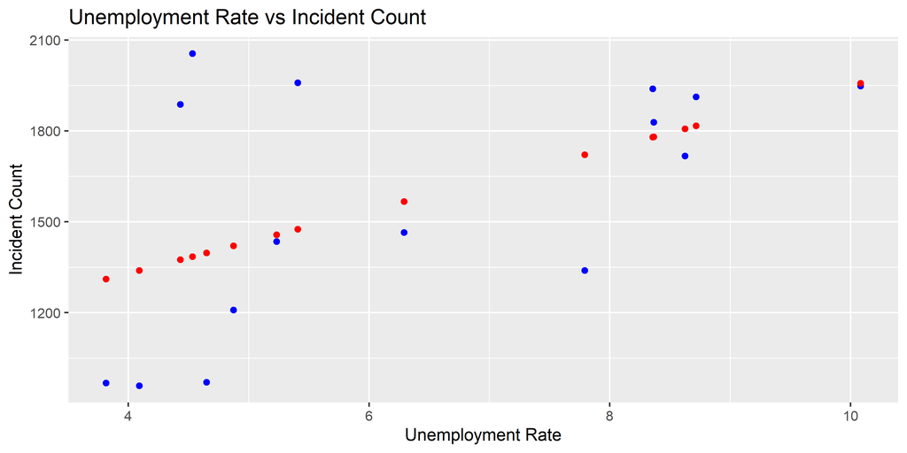

```r
## get the New York Unemployment data from Federal Reserve Bank of St. Louis

ny_unemployment_data_url <-"https://fred.stlouisfed.org/graph/fredgraph.csv?bgcolor=%23e1e9f0&chart_type=line&drp=0&fo=open%20sans&graph_bgcolor=%23ffffff&height=450&mode=fred&recession_bars=on&txtcolor=%23444444&ts=12&tts=12&width=1168&nt=0&thu=0&trc=0&show_legend=yes&show_axis_titles=yes&show_tooltip=yes&id=NYUR&scale=left&cosd=1976-01-01&coed=2021-12-01&line_color=%234572a7&link_values=false&line_style=solid&mark_type=none&mw=3&lw=2&ost=-99999&oet=99999&mma=0&fml=a&fq=Monthly&fam=avg&fgst=lin&fgsnd=2020-02-01&line_index=1&transformation=lin&vintage_date=2022-01-30&revision_date=2022-01-30&nd=1976-01-01"

ny_unemployment_data <- read_csv(ny_unemployment_data_url)
## tidy and clean the data to get Annual Unemployment Rate
ny_unemployment_data <- ny_unemployment_data%>%
  mutate(year=year(DATE)) %>%
  group_by(year) %>%
  summarize(UER=mean(NYUR)) %>%
                            ungroup()

## try to get shooting incident per yeam
nypd_total_shooting_by_year <- nypd_boro_shooting_by_year %>%
                              group_by(year) %>%
                             summarize(total_incidents=sum(incident_per_year)) %>%
                            ungroup()

incidents_vs_uemployment <- nypd_total_shooting_by_year %>%
            left_join(ny_unemployment_data)
mod <- lm(total_incidents ~ UER, data=incidents_vs_uemployment)

nypd_incident_w_pred <- incidents_vs_uemployment %>% mutate(pred=predict(mod))


nypd_incident_w_pred_plot <- nypd_incident_w_pred %>% ggplot() +
  geom_point(aes(x=UER, y=total_incidents), color="blue") +
   geom_point(aes(x=UER, y=pred), color="red")+
  labs(x="Unemployment Rate", y="Incident Count",
title="Unemployment Rate vs Incident Count")

ggsave("nypd_incident_w_pred_plot.png", nypd_incident_w_pred_plot,
       height=4, width=8, units="in",  dpi=450)

knitr::include_graphics("nypd_incident_w_pred_plot.png")
```

## Conclusion

The linear model is showing the correlation between high incidents and high unemployment Rate but this needs improvement when the unemployment rate is low. As we can see the model is not predicting the correct relationship when the unemployment rate is less than 5%.

## Bias in my Analysis

I can potentially see the biases in my analysis by treating all the boroughs and people the same but the crime rate depends on a lot of factors depending on Social economical factors like income, race, and political leaning.